# Plankton-DOM Modelling

Matthew Talluto

27.07.2021

# Methods

## Model design

Because the experiment was replicated in time, we needed a model structure that accounts for statistical non-independence. Moreover, because observations were of abundances, we needed a non-linear model that accounted for population growth. We used a hierarchical Bayesian model, implemented in the Stan programming language and fit using the R-package `rstan` (R Core Team 2021, Stan Development Team 2020).

We considered a simple exponential growth to describe the change in abundance over time:

$$\begin{aligned}
N_{t,i} & = N_{0,i}e^{r_{t,i}t} \\
N_{t,i} & = N_{t-1,i}e^{r_{t,i}}
\end{aligned}$$

where $N_{t,i}$ is the abundance at time $t$ (in units of 3 days for our experiment) for response variable $i$ (i.e., either bacterial, algal, or zooplankton abundance), and $r_{t,i}$ is the the rate of increase of population $i$ at time $t$. The growth rate is variable in time to account for the second DOM pulse which was applied halfway through the experiment. We were interested in the effect of the experimental treatments on the parameter $r$, which we modelled with the following regression equation:

$$r_{t,i,j} = a_{i,j} + b_{div,i}D_{j} + b_{pre,i}\mathrm{Pr}_{j} + b_{post,i}\mathrm{Po}_{t} +
b_{d \times pr,i}D_j \mathrm{Pr}_{j} + b_{d \times po}D_j\mathrm{Po}_{t} +
b_{pr \times po}\mathrm{Pr}_{j}\mathrm{Po}_{t}$$

Here, the subscript $t$ indicates the time step, $i$ indexes the three different response variables, and $j$ indexes the experimental flumes (to allow for random effects by subject). $D_j$ is an indicator variable that is 1 if flume $j$ was a high-diversity treatment, and 0 otherwise, $\mathrm{Pr}_{j}$ indicates whether flume $j$ got a DOM pre-treatment, and $\mathrm{Po}_{t}$ indicates whether time $t$ was after the DOM pulse halfway through the experiment. All $b$ parameters are the effect sizes of the various treatment combinations.

This model includes all two-way interactions. A key assumption of this model is that $r$ can only change due to treatment conditions; there is no change in $r$ in time except for a single change immediately following the DOM pulse. This may be unrealistic, since as DOM is consumed following additions, growth rates may change due to changes in the turbidity of the water.

Finally, we predicted the abundance of each group using the modelled growth rate, and then used a lognormal likelihood function to evaluate the model fit:

$$\begin{aligned}
\hat{N_{t,i,j}} & = N_{t-1,i,j}e^{r_t,i,j} \\
\log N_{t,i,j} & \sim \mathbb{N}(\log \hat{N_{t,i,j}}, \sigma_i)
\end{aligned}$$

Here, $\sigma_i$ is the residual standard deviation for response variable $i$. This formulation assumes that the three response variables are independent of one another. however, this is unlikely to be true if top-down or bottom-up control can influence population growth between trophic levels. Thus, we fit an additional model that account for the correlation among response variables; the parameter estimates of this model can be interpreted as the residual effect of the experimental treatments, after accounting for correlations among the population sizes of the different groups. This model was identical to the model described above, with the exception of the likelihood function:

$$\log N_{t,j} \sim \mathbb{MN}(\log \hat{N_{t,j}}, \Sigma)$$

Here, $N_{t,j}$ is a vector of abundances (i.e., the abundances of all three populations), fit with a multivariate normal distribution. The variance-covariance matrix $\Sigma$ describes how the three response variables influence each other. We expected this model to produce less biased parameter estimates because the correlations among responses are included in the model.

# Results

## Parameter estimates

The figure below shows parameter estimates for both uni- and multivariate models, with the IQR and 95% credible intervals. A brief summary of the significant effects for each response:

**Algae**

- Diversity (-)
- DOM pretreatment (-)
- DOM pulse (-)
- Diversity × DOM pulse (+)
- DOM pretreatment × DOM pulse (+)

For algae, both DOM treatments had a negative effect. However, the high diversity treatment offset the negative effect of the DOM pulse, as did the DOM pretreatment.

**Bacteria**

- DOM pretreatment (+)
- DOM pulse (+)
- Diversity × DOM pulse (+)
- DOM pretreatment × DOM pulse (-)

In bacteria, both DOM treatments had a positive effect. The effect of the DOM pulse was stronger in the high-diversity treatments. There was a strong negative effect of having both DOM treatments. Bacteria getting a DOM pre-treatment began growing faster immediately, and the second DOM pulse did not increase the growth rate further. Bacteria with no DOM pre-treatment saw an increase in growth after the second pulse.

**Zooplankton**

- DOM pretreatment (+)
- DOM pulse (+)
- DOM pretreatment × DOM pulse (-)

The effects for zooplankton were very similar to those for bacteria, but there was no effect of diversity.

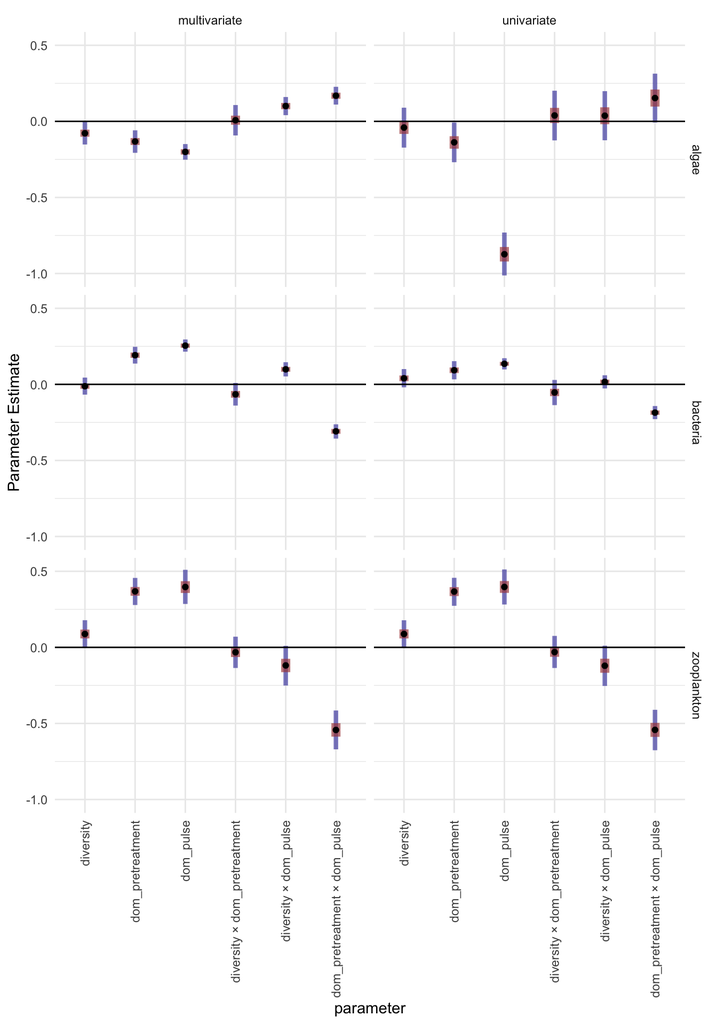

**Figure 1.** Model parameter estimates. Values give the median effect of each factor on the $r$ parameter describing the growth of the response in time. The wide interval gives the interquartile range, the narrow interval is a 95% credible interval.

## Residual correlations

The model detected negative residual correlations between algae and both other groups, and a positive correlation between bacteria and zooplankton.

|  | bacteria | algae | zooplankton |
| --- | --- | --- | --- |
| bacteria |  |  |  |
| algae | -0.137 (-0.253,-0.015) |  |  |
| zooplankton | 0.434 (0.329,0.528) | -0.212 (-0.315,-0.105) |  |

### Predicted growth

Here we compare the predicted growth curves for a generic flume against the observed curves for all three responses. We use a log scale for abundance, because of the lognormal likelihood, and because the exponential function produces quite wide intervals at the later time steps.

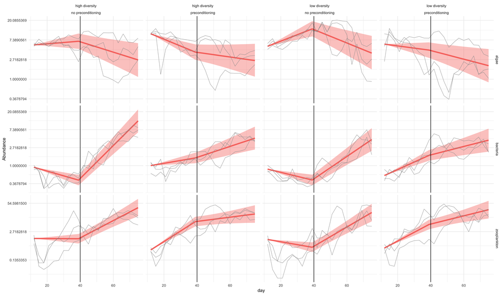

**Figure 2.** Predicted median change in abundances for each treatment combination. Gray lines show the observed abundances for each individual replicate. Ribbons show 90% credible intervals for the mean abundance at a particular time.−

# References

R Core Team (2021). R: A language and environment for statistical computing. R Foundation for Statistical Computing, Vienna, Austria. URL https://www.R-project.org/.

Stan Development Team (2020). RStan: the R interface to Stan. R package version 2.21.2. http://mc-stan.org/.